# USAPL Weightcalss Composition by Year

Yulia Zamriy

December 6, 2017

## Overview

The main goal of this document is to outline all the steps for creating a figure that:

- Contains weight class composition (%) at USAPL Raw Nationals by Year
- Splits Male vs. Female classes
- Has a table with total lifters each year by gender

Please note, that this is part of a bigger analysis. Hence, not all the background information is provided. For more details see [here](https://github.com/YuliaZamriy/USAPL)

### Requirements

The following packages need to be installed:

```r
library(tidyverse)
library(ggplot2)
library(gridExtra)
library(grid)
```

The below .csv file is available for download [here](https://github.com/YuliaZamriy/USAPL/tree/master/Nationals/CSV)

```r
WclassData <- read_csv("./CSV/Raw2014_2016_Weightclass.csv")
```

### Data description

This dataset contains a subset of the USAPL Raw Nationals results for 2014-2017:

- Open Divisions only
- First column is row counter to hide lifter names. It will be ignored in this report
- Sex (Factor) Data analysis will be split by gender
- Year (Integer) Year of the competition
- Weightclass (Character) Weight classes. “-” indicates under specified weight. “+” specified weight and above
- Weightclass_Num (Integer) Weight classes transformed into numbers. Two “+” classes (84+, 120+) are coded as 85 and 121

```r
str(WclassData)
```

```
## Classes 'tbl_df', 'tbl' and 'data.frame':    1717 obs. of  5 variables:
##  $ X1             : int  1 2 3 4 5 6 7 8 9 10 ...
##  $ Sex            : chr  "Female" "Female" "Female" "Female" ...
##  $ Year           : int  2014 2014 2014 2014 2014 2014 2014 2014 2014 2014 ...
##  $ Weightclass    : chr  "-57" "-72" "-72" "-43" ...
##  $ Weightclass_Num: int  57 72 72 43 57 63 72 84 47 52 ...
##  - attr(*, "spec")=List of 2
##   ..$ cols   :List of 5
##   .. ..$ X1             : list()
##   .. .. ..- attr(*, "class")= chr  "collector_integer" "collector"
##   .. ..$ Sex            : list()
##   .. .. ..- attr(*, "class")= chr  "collector_character" "collector"
##   .. ..$ Year           : list()
##   .. .. ..- attr(*, "class")= chr  "collector_integer" "collector"
##   .. ..$ Weightclass    : list()
##   .. .. ..- attr(*, "class")= chr  "collector_character" "collector"
##   .. ..$ Weightclass_Num: list()
##   .. .. ..- attr(*, "class")= chr  "collector_integer" "collector"
##   ..$ default: list()
##   .. ..- attr(*, "class")= chr  "collector_guess" "collector"
##   ..- attr(*, "class")= chr "col_spec"
```

```r
table(WclassData$Sex)
```

```
##
## Female   Male
##    725    992
```

```r
table(WclassData$Year)
```

```
##
## 2014 2015 2016 2017
##  216  506  450  545
```

```r
table(WclassData$Weightclass, WclassData$Weightclass_Num)
```

```
##
##         43  47  52  57  59  63  66  72  74  83  84  85  93 105 120 121
##   -105   0   0   0   0   0   0   0   0   0   0   0   0   0 191   0   0
##   -120   0   0   0   0   0   0   0   0   0   0   0   0   0   0  95   0
##   -43    1   0   0   0   0   0   0   0   0   0   0   0   0   0   0   0
##   -47    0  28   0   0   0   0   0   0   0   0   0   0   0   0   0   0
##   -52    0   0  54   0   0   0   0   0   0   0   0   0   0   0   0   0
##   -57    0   0   0 112   0   0   0   0   0   0   0   0   0   0   0   0
##   -59    0   0   0   0  28   0   0   0   0   0   0   0   0   0   0   0
##   -63    0   0   0   0   0 181   0   0   0   0   0   0   0   0   0   0
##   -66    0   0   0   0   0   0  67   0   0   0   0   0   0   0   0   0
##   -72    0   0   0   0   0   0   0 168   0   0   0   0   0   0   0   0
##   -74    0   0   0   0   0   0   0   0 121   0   0   0   0   0   0   0
##   -83    0   0   0   0   0   0   0   0   0 193   0   0   0   0   0   0
##   -84    0   0   0   0   0   0   0   0   0   0  98   0   0   0   0   0
##   -93    0   0   0   0   0   0   0   0   0   0   0   0 240   0   0   0
##   120+   0   0   0   0   0   0   0   0   0   0   0   0   0   0   0  57
##   84+    0   0   0   0   0   0   0   0   0   0   0  83   0   0   0   0
```

### Data transformation

First, I need to do some basic transformation to make the data more suitable for this analysis

Weightclass_Num is converted into a factor variable to make labels on the charts appear in the correct order and with correct weight class names

```r
Female <- c('-43', '-47', '-52', '-57', '-63', '-72', '-84', '84+')
Male <- c('-40','-53', '-59', '-66', '-74', '-83', '-93', '-105', '-120', '120+')

WclassData <- mutate(WclassData,
                    Weightclass_Num = factor(Weightclass_Num,
                                             levels = c(43, 47, 52, 57, 63, 72, 84, 85,
                                                        40, 53, 59, 66, 74, 83, 93, 105, 120, 121),
                                             labels = c(Female, Male)))
```

### Data aggregation

To create plots with labels let’s:

- Aggregate data by Year and Weight Class, separately for Male vs. Female
- Manually create variables containing labels as % and label positions (relative to the y axis on the chart)

```r
wc_split_f <-
    WclassData %>%
    filter(Sex == "Female") %>%
    group_by(Year, Weightclass_Num) %>%
    summarize(NLifters = n()) %>%
    mutate(perc = 100*NLifters/sum(NLifters),
           label = ifelse(perc > 2.5, paste0(round(perc,0),"%"), ""),
           labpos = ifelse(cumsum(perc) >= 97 , 3,
                        ifelse(cumsum(perc) <= 3, 99,
                               100 - cumsum(perc) + 3)))

wc_split_m <-
    WclassData %>%
    filter(Sex == "Male") %>%
    group_by(Year, Weightclass_Num) %>%
    summarize(NLifters = n()) %>%
    mutate(perc = 100*NLifters/sum(NLifters),
           label = ifelse(perc > 2, paste0(round(perc,0),"%"), ""),
           labpos = ifelse(cumsum(perc) >= 97 , 3,
                        ifelse(cumsum(perc) <= 3, 99,
                               100 - cumsum(perc) + 3)))
```

### Building pieces of the figure

Since I am building two identical charts (Female vs. Male), it is convenient to create a custom theme variable first

```r
theme_classic_adj <-
    theme_classic() +
    theme(line = element_blank(),
          axis.text.y = element_blank(),
          axis.title.y = element_blank(),
          axis.text.x = element_text(size = rel(1.2), face = "bold", color = "grey40"),
          axis.title.x = element_text(size = rel(1.5), color = "grey40"),
          strip.text = element_text(size = rel(1.2), face = "bold", color = "grey40"),
          strip.background = element_rect(color = "grey40"),
          plot.title = element_text(hjust = 0.03, face = "bold.italic", color = "grey60"))
```

Then I am building stacked bar charts (each column adds to 100%) and manually created labels at the desired positions

```r
plot_f <- ggplot(wc_split_f, aes(x = Year, y = perc, fill = Weightclass_Num)) +
        geom_bar(stat = "identity") +
        geom_text(aes(label = label, y = labpos),
                  color = "grey10",
                  fontface = "bold") +
        labs(fill = "Weightclass", x = NULL, title = "Female Divisions") +
        scale_fill_brewer(palette = "Spectral") +
        theme_classic_adj

plot_m <- ggplot(wc_split_m, aes(x = Year, y = perc, fill = Weightclass_Num)) +
    geom_bar(stat = "identity") +
    geom_text(aes(label = label, y = labpos),
              color = "grey10",
              fontface = "bold") +
    labs(fill = "Weightclass", x = NULL, title = "Male Divisions") +
    scale_fill_brewer(palette = "Spectral") +
    theme_classic_adj
```

I want to add a table under the charts with total lifter count each year. For that I need to further summarize the data and transpose it, so it appears as a row

```r
count_f1 <- wc_split_f %>%
    group_by(Year) %>%
    summarize(NLifters = sum(NLifters)) %>%
    t() %>%
    data.frame()

count_m1 <- wc_split_m %>%
    group_by(Year) %>%
    summarize(NLifters = sum(NLifters)) %>%
    t() %>%
    data.frame()
```

Then I convert these two small datasets into “table grobs” using common theme

```r
tt <- ttheme_minimal(core=list(fg_params=list(fontface=2, col="white", fontsize = 10),
                                bg_params = list(fill = "grey40", col=NA)))

count_f2 <- tableGrob(count_f1[2,], cols = NULL, rows = NULL, theme = tt)
count_f2$widths <- unit(rep(1/ncol(count_f2), ncol(count_f2)), "npc")

count_m2 <- tableGrob(count_m1[2,], cols = NULL, rows = NULL, theme = tt)
count_m2$widths <- unit(rep(1/ncol(count_m2), ncol(count_m2)), "npc")
```

### Assembling pieces into the figure

First, I’ll combine two created table grobs the following way:

- Text label (Number of Lifters) that is created as “text grob”
- First table grob
- Blank space “rect grob”
- Second table grob
- Space allocated to each is arbitrary

```r
countlab <- textGrob("Number\nof Lifters",
                 gp = gpar(col = "grey40", fontsize = 10, fontface = "bold"))

blank <- rectGrob(gp = gpar(col = "white"))

counttab <-
    arrangeGrob(countlab, count_f2, blank, count_m2, blank, nrow=1, widths = c(0.15,0.3,0.18,0.3,0.17))
```

Second, I combine two stacked bar charts. I add empty space (rect grob) first to make it align better with the table created in the previous step

```r
plots_fm <-
    arrangeGrob(blank, plot_f, plot_m, ncol=3, widths = c(0.12, 0.44, 0.44))
```

Third, I create text grobs for the main figure title and a note on the bottom

```r
title <- textGrob("Weightclass Composition* at USAPL Raw Nationals by Year, Open Division",
                 gp = gpar(col = "grey40", fontsize = 15, fontface = "bold"))

note <- textGrob("* Weightclasses with less than 2% of lifters do not have value labels for aesthetics reasons",
                 gp = gpar(col = "grey40", fontsize = 8, fontface = "italic"))
```

Finally! Piecing it all together!

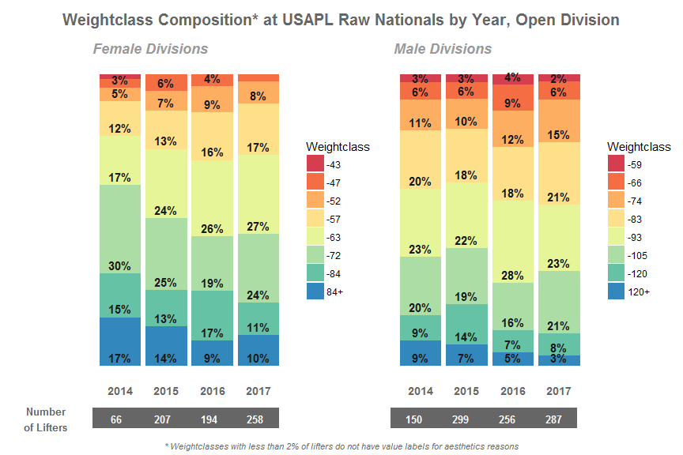

```r
grid.newpage()
grid.arrange(arrangeGrob(title, plots_fm, counttab, note, nrow=4, heights = c(0.1, 1, 0.1, 0.05)))
```

And saving a png file just in case.

```r
png(file = "./Charts/Weightclasses distribution Open.png", width=600, height=400)
grid.arrange(arrangeGrob(title, plots_fm, counttab, note, nrow=4, heights = c(0.1, 1, 0.1, 0.05)))
dev.off()
```